# Natural Language Processing: Text Prediction

Data Science Capstone – Milestone Report

Karthik Arumugham

22 June 2016

## Abstract

Natural Language Processing (NLP) is an area of analysis that has great and valuable applications in common daily tasks. It has been used as part of enhanced texting tools such as Swiftkey, anticipate search terms in Google, spell check errors and helping people with speech disabilities. NLP requires a collection of written texts with a common author, source, subject of type (Corpus), and the framework to manipulate it. To facilitate typing on mobile devices, SwiftKey, our corporate partner in this capstone project, builds a smart keyboard that makes it easier for people to type on their mobile devices. One cornerstone of their smart keyboard is predictive text models.

## Synopsis

The main goal of this project is to build the next word predictive model given an input word/sentence fragment within the realm of natural language processing. To do, this we are given 3 corpus in three 4 different languages – English, German, Finnish and Russian. But, I chose to only use the English language. There are three different documents that make up the corpus - texts from Twitter feed, news feed, and a blog.

## Dataset

The data is originally from: [HC Corpora](http://www.corpora.heliohost.org). The datasets for this project can be downloaded from [Coursera-SwiftKey Datasets](https://d396qusza40orc.cloudfront.net/dsscapstone/dataset/Coursera-SwiftKey.zip).

As the file sizes are too large, a small 10% random sample of the files have been considered and loaded.

## Data Cleaning

```
## [1] "Set of unique characters after ASCII conversion"
##  [1] ""   "`"  "^"  "~"  "<"  "="  ">"  "|"  " "  "_"  "-"  ","  ";"  ":"
## [15] "!"  "?"  "/"  "."  "'"  "("  ")"  "["  "]"  "{"  "}"  "@"  "$"  "*"
## [29] "\\" "&"  "#"  "%"  "+"  "0"  "1"  "2"  "3"  "4"  "5"  "6"  "7"  "8"
## [43] "9"  "a"  "b"  "c"  "d"  "e"  "f"  "g"  "h"  "i"  "j"  "k"  "l"  "m"
## [57] "n"  "o"  "p"  "q"  "r"  "s"  "t"  "u"  "v"  "w"  "x"  "y"  "z"
```

The following steps were taken to handle the remaining special characters.

```
## [1] "Final set of unique characters"
##  [1] ""  "." " " "0" "1" "2" "3" "4" "5" "6" "7" "8" "9" "a" "b" "c" "d"
## [18] "e" "f" "g" "h" "i" "j" "k" "l" "m" "n" "o" "p" "q" "r" "s" "t" "u"
## [35] "v" "w" "x" "y" "z"
```

**Summary stats on sentence length before & after pruning:**

```
##         Min Q1 Median   Mean Q3 Max
## Blogs     1  6     11 12.760 18 182
## News      1  7     14 14.580 21 207
## Twitter   1  3      6  7.202 10  32
##         Min Q1 Median  Mean Q3 Max
## Blogs     5  8     11 11.60 15  20
## News      6  9     13 12.82 16  20
## Twitter   6  7      9 10.11 12  20
```

## Tokenization

In this step the sentences are broken down into groups of words each of length 1 to 4 called ngrams. For example, the 4-grams for the sentence “*the rain in Spain falls mainly on the plain*”,“*economic news has little effect on financial markets*” would be,

```
##  [1] "the rain in Spain"           "rain in Spain falls"
##  [3] "in Spain falls mainly"       "Spain falls mainly on"
##  [5] "falls mainly on the"         "mainly on the plain"
##  [7] "economic news has little"    "news has little effect"
##  [9] "has little effect on"        "little effect on financial"
## [11] "effect on financial markets"
```

It is important to note that the ngrams are formed only within the boundary of the sentence (i.e.,) ngrams between sentences such as “*on the plain economic*”, “*the plain economic news*”, etc are not formed. The NGramTokenizer from RWeka package takes care of this by default. The frequencies are also recorded. This will help us find the probabilities of occurrence for each of the ngrams.

**Total n-gram generated:** The frequencies of the n-gram terms are very sparsely distributed, approximate 90% of terms are very rarely used, only appears couple times, they are of no use for training the word predicting model and can be ignored for quick predictions. Appendix 2 shows the plot of the Top 20 ngrams from the combined corpus. Appendix 3 shows the plot of ngram frequencies and is evident that the ngrams are sparse.

```
##          Blogs    News Twitter  Corpus
## 1-gram   81986   56765   35930  112268
## 2-gram  992171  597138  262434 1554218
## 3-gram 1950157 1025266  421886 3196033
## 4-gram 2194259 1090395  425402 3646858
```

**Top 10 1-grams:**

```
##    Blog  Freq News  Freq Twitter  Freq Corpus   Freq
## 1   the 99627  the 50288     the 19517    the 169432
## 2   and 74727  and 31150       i 19411    and 118267
## 3    to 70087   to 30333      to 17293     to 117713
## 4     a 59485    a 28436       a 13398      a 101319
## 5    of 59259   of 26241      is 13297     of  93827
## 6     i 55334    n 24639     you 13097      i  81493
## 7    in 44287   in 24180     and 12390     in  77478
## 8    is 43101   is 17164       n 10141     is  73562
## 9  that 36151 that 14358     for  9091      n  61855
## 10   it 33587  for 13669      in  9011   that  57120
```

**Top 10 2-grams:**

```
##      Blog Freq    News Freq    Twitter Freq  Corpus  Freq
## 1  in the 7056  in the 3613       i am 3445  in the 12172
## 2   it is 6184  of the 2925      it is 2295   it is 11214
## 3  of the 5503   it is 2735     do not 2253    i am  9513
## 4    i am 5230  on the 1695    for the 1629  of the  9244
## 5  do not 5122   to be 1663     in the 1503  do not  8774
## 6  i have 4652    is a 1604    you are 1358   to be  7273
## 7   to be 4556  to the 1556    can not 1330    is a  6478
## 8    is a 3945    in a 1412    that is 1225  on the  6346
## 9  on the 3681  do not 1399     i have 1117  i have  6242
## 10 to the 3523 he said 1390 thanks for 1075 for the  5927
```

```
##           Blog Freq         News Freq            Twitter Freq      Corpus
## 1     i do not 1635   n year old  453           i do not  613    i do not
## 2   one of the  876  more than n  437     thanks for the  569    a lot of
## 3     a lot of  823     a lot of  430       can not wait  411  one of the
## 4    i did not  717     i do not  382          i can not  400     it is a
## 5  i have been  674   one of the  379           i am not  251   i can not
## 6      it is a  654      it is a  371        do not know  224 do not know
## 7    i can not  653 n percent of  286 looking forward to  209   i did not
## 8   if you are  626   there is a  238         you do not  204  if you are
## 9  do not know  618    it is not  231        not wait to  203    i am not
## 10    i am not  565      the u s  216          i will be  196  there is a
##    Freq
## 1  2630
## 2  1396
## 3  1389
## 4  1213
## 5  1123
## 6  1010
## 7  1000
## 8   932
## 9   930
## 10  900
```

```
##                  Blog Freq             News Freq               Twitter
## 1       i do not know  373     a n year old  122       can not wait to
## 2      i do not think  206   the n year old  116 thanks for the follow
## 3      do not want to  205    i do not know   99         i do not know
## 4       i am going to  198   i do not think   95        i can not wait
## 5       if you do not  192   do not want to   80         i am going to
## 6       i do not have  154   is going to be   74        is going to be
## 7    at the same time  145    at the end of   65      can not wait for
## 8     i would like to  133  we are going to   64       not wait to see
## 9  for the first time  132    is one of the   59        i do not think
## 10      i do not want  132 at the same time   57     thank you for the
##    Freq             Corpus Freq
## 1   201      i do not know  584
## 2   156     i do not think  368
## 3   112     do not want to  348
## 4   106      i am going to  342
## 5   105    can not wait to  318
## 6   105     is going to be  296
## 7    71      if you do not  272
## 8    71   at the same time  229
## 9    67      i do not have  222
## 10   66 for the first time  218
```

## Word Prediction Algorithm

There are various techniques. The most common is the Simple Good Turing. So given any phrase or sentence, only the last few words are considered to form ngrams - 1,2,3. First the 3-gram is searched in the 4-gram table. If the input phrase is not in 4-gram table, the 3-gram table is considered. If there are matches, the trigrams with the highest probability are considered for the prediction. The end words that complete the selected trigrams are the new predicted words. But the limitation is that the probabilities are heavily dependent on the individual ngram sample size and not across different ngrams. One way to overcome this is to use the markov chain probability property `P(A,B) = P(B|A) * P(A)`.

For example, `P(I do not know) = P(know|I do not) * P(not|I do) * P(do|I) * P(I)`. From the below consolidated probability table (top 2 rows): `P(I do not know) = 1.492427e-04 * 0.0006115575 * 0.0007181714 * 0.01584086 = 1.038334e-12`

```
##      Gram3 Gram2 Gram1  Word Freq          Gram4         P1           P2
## 1 i do not  i do     i  know  584  i do not know 0.01584086 0.0007181714
## 2 i do not  i do     i think  368 i do not think 0.01584086 0.0007181714
##             P3           P4            P
## 1 0.0006115575 1.492427e-04 1.038334e-12
## 2 0.0006115575 9.404333e-05 6.542928e-13
```

Top 20 predictions for the sentence *“When you were in Holland you were like 1 inch away from me but you hadn’t time to take a”*

```
##  [1] "look"     "picture"  "photo"    "n"        "shower"   "break"
##  [7] "of"       "step"     "nap"      "lead"     "quick"    "long"
## [13] "breather" "couple"   "few"      "trip"     "bath"     "class"
## [19] "stand"    "with"
```

First `to take a` is checked with 3-grams. If the predicted results are few then `take a` is checked with 2-grams and finally `a` with 1-grams.

# Next Steps

- Implement an advanced prediction model.
- Explore ways to improve efficiency and accuracy.
- Implement model as a Shiny App (mobile responsive)

## Appendix

1. **Resources Used**
- Machine: Amazon EC2 m4.4xlarge instance (16 Cores, 64GB RAM)
- AMI: RStudio-0.99.491_R-3.2.3_ubuntu-14.04-LTS-64bit (ami-b277bad1)
- Time:
  - Data Cleaning: ~ 40 minutes
  - N-grams: ~ 10 minutes
  - Probability table: ~ 10 minutes
- CPU Utilization:

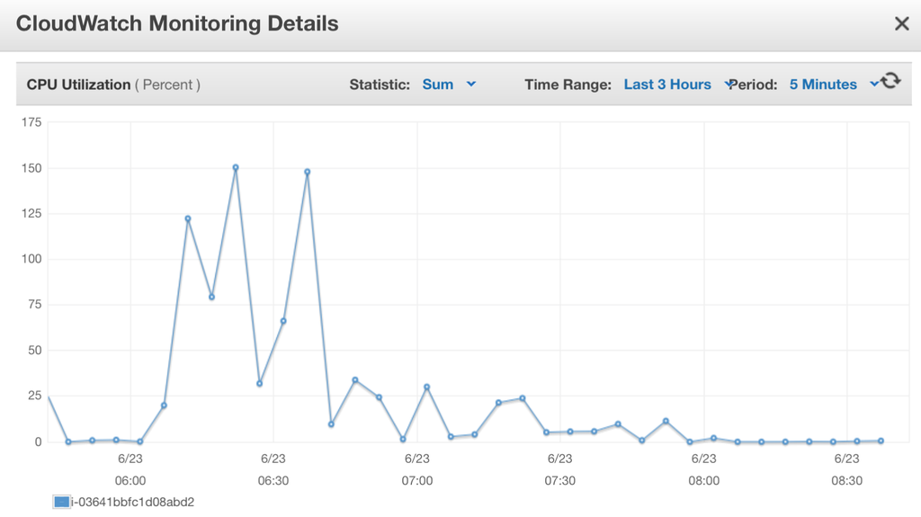

2.**Plot of Top 20 ngrams from the combined corpus**

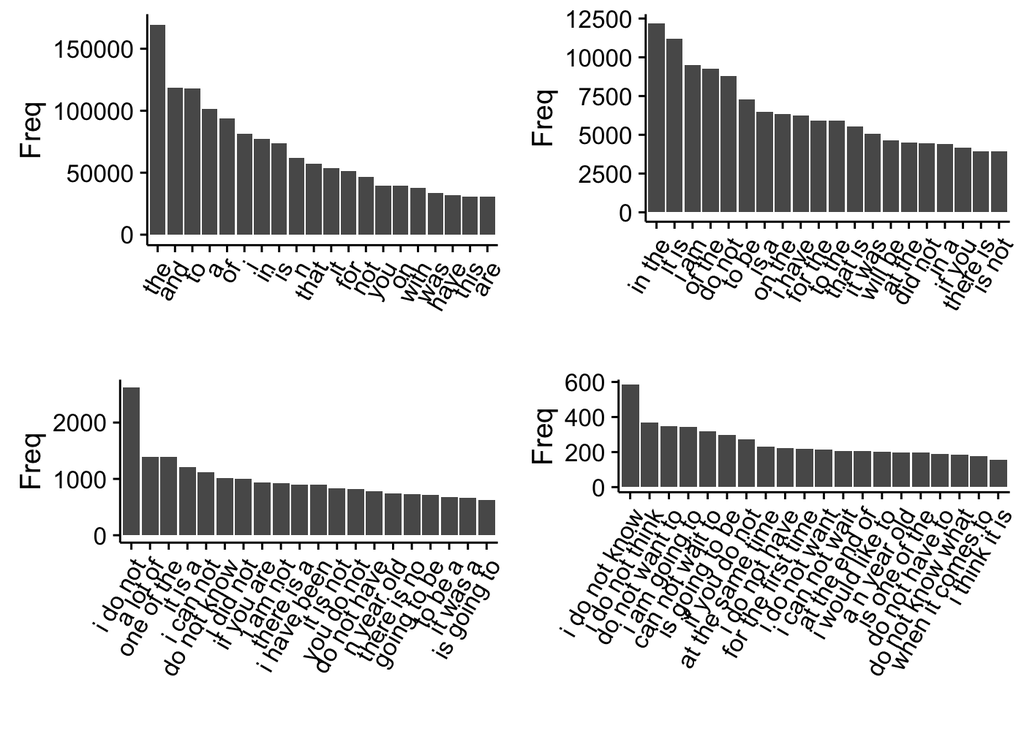

3.**Plot of ngram frequencies**

```
## numeric(0)
## numeric(0)
## numeric(0)
```

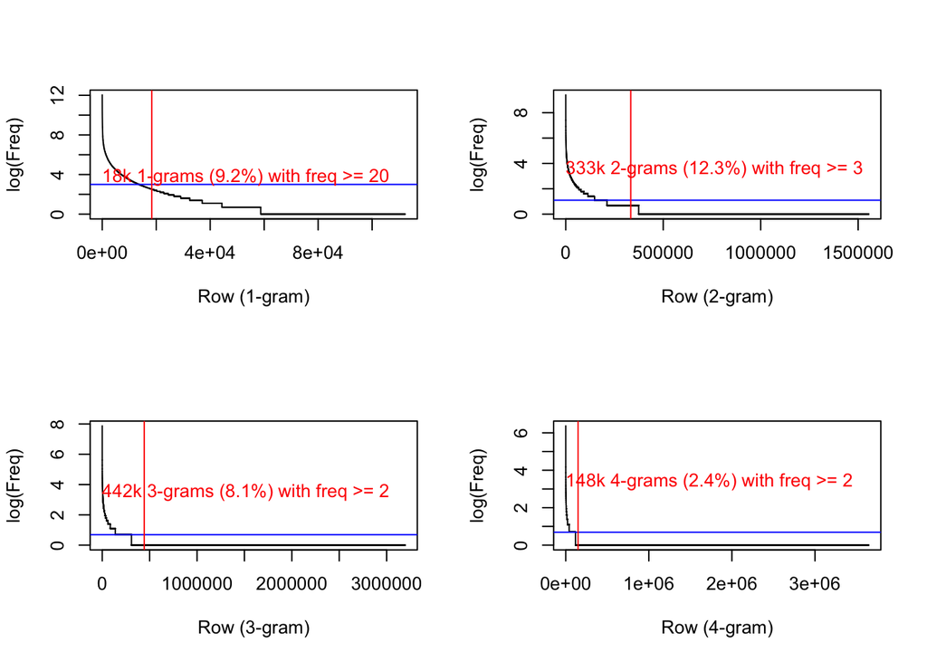

```
## numeric(0)
```